# Load Data

```python
import pandas as pd

df_SiriVoiceLogs = pd.read_csv('https://storage.googleapis.com/datalynn-datasets/interview-challenge/technology/Apple_Siri_Voice/df_SiriVoiceLogs.csv')
```

# Solution

## Question 1: **Data Manipulation & Cleaning:**

Scenario: During a preliminary analysis, you noticed that some of the `DateTime` entries in the SiriVoiceLogs table were entered as mere dates without time. Using Python and the dataframes, please clean these records and assume a standard time for them. Additionally, for accents with less than 100 entries, label them as 'Others'.

**Hints:**

1. **Data Cleaning for DateTime**:
   - First, we'll identify rows where the `DateTime` column only contains date without time.
   - We'll then assign a standard time for these rows.
2. **Labeling Accents**:
   - We'll group the data by 'Accent' and count the number of entries for each accent.
   - Accents with less than 100 entries will be labeled as 'Others'.

**1. Data Cleaning for DateTime**

Explanation: We can identify DateTime entries without time by their string length. Typically, a YYYY-MM-DD formatted date has a string length of 10. Any entry longer than this will have both date and time.

```python
# 1. Data Cleaning for DateTime
import pandas as pd

# Assuming df_SiriVoiceLogs has been loaded
# Replace DateTime entries with only date by adding a standard time (e.g., 12:00:00)
standard_time = " 12:00:00"
df_SiriVoiceLogs['DateTime'] = df_SiriVoiceLogs['DateTime'].apply(lambda x: x + standard_time if len(x) == 10 else x)
```

```python
# 2. Labeling Accents
# Convert DateTime column to pandas datetime format if it's not already
df_SiriVoiceLogs['DateTime'] = pd.to_datetime(df_SiriVoiceLogs['DateTime'])

# Check if the time part is midnight and replace with standard time (e.g., 12:00:00 PM)
standard_hour = 12
mask_time = (df_SiriVoiceLogs['DateTime'].dt.hour == 0) & (df_SiriVoiceLogs['DateTime'].dt.minute == 0) & (df_SiriVoiceLogs['DateTime'].dt.second == 0)
df_SiriVoiceLogs.loc[mask_time, 'DateTime'] = df_SiriVoiceLogs.loc[mask_time, 'DateTime'] + pd.to_timedelta(standard_hour, unit='h')
df_SiriVoiceLogs.head(10)
```

|  | UserID | Command | DateTime | Region | Accent | Success | Device | Feedback |
| --- | --- | --- | --- | --- | --- | --- | --- | --- |
| 0 | 1 | Ask about the weather | 2023-05-15 16:46:00 | Australia | Others | 1 | iPhone | NaN |
| 1 | 2 | Ask about the weather | 2023-08-08 03:58:00 | Asia | Others | 0 | iPad | NaN |
| 2 | 3 | Play music | 2023-01-19 06:13:00 | Africa | Others | 1 | iPhone | NaN |
| 3 | 4 | Play music | 2023-07-21 03:39:00 | North America | Southern | 0 | Mac | NaN |
| 4 | 5 | Send a message | 2023-05-04 12:00:00 | Africa | Others | 0 | iPhone | NaN |
| 5 | 6 | Set an alarm | 2023-02-04 12:00:00 | Asia | Others | 1 | iPad | NaN |
| 6 | 7 | Send a message | 2023-02-14 21:48:00 | Europe | German | 1 | iPhone | NaN |
| 7 | 8 | Send a message | 2023-05-15 07:15:00 | Asia | Others | 0 | iPad | NaN |
| 8 | 9 | Ask about the weather | 2023-03-13 02:02:00 | Asia | Others | 1 | Mac | NaN |
| 9 | 10 | Play music | 2023-02-27 12:32:00 | Australia | Others | 1 | Mac | NaN |

## Question 2: **Probability and Statistics:**

Scenario: Given the immense diversity in accents, you wonder how consistent Siri's success rate is across various regions and accents. Can you construct a confidence interval for the success rate of Siri's understanding for each major accent in the dataset?

**Hints:**

1. **Compute the Success Rate for Each Accent**: Calculate the ratio of successful commands to total commands for each major accent.
2. **Compute the Confidence Interval**: Use the formula for the confidence interval for a proportion to get the interval for each major accent. For this problem, we'll use a 95% confidence interval, which corresponds to 1.96 standard deviations from the mean for a normal distribution.
3. **Visualize the Results**: A bar chart with error bars showing the confidence interval for each accent would be a clear way to display the results.

**1. Compute the Success Rate for Each Accent:**

```python
# 1. Compute the Success Rate for Each Accent:
import pandas as pd

# Grouping the dataframe by 'Accent' and calculating the success rate
accent_success = df_SiriVoiceLogs.groupby('Accent').agg(
    total_commands=pd.NamedAgg(column="Success", aggfunc="count"),
    successful_commands=pd.NamedAgg(column="Success", aggfunc="sum")
)

accent_success['success_rate'] = accent_success['successful_commands'] / accent_success['total_commands']
```

**2. Compute the Confidence Interval:**

For a binary outcome like success/failure, the variance for a proportion $ p $ is given by $p(1-p)$. The standard error (SE) is:

$SE = \sqrt{\frac{p(1-p)}{n}}$

Where:

- $p$ = proportion of successes.
- $n$ = total number of trials.

The 95% confidence interval is given by:

$ p \pm 1.96 * SE $

```python
# 2. Compute the Confidence Interval:
import numpy as np

# Calculate the standard error and the margins of error for the confidence interval
accent_success['standard_error'] = np.sqrt(accent_success['success_rate'] * (1 - accent_success['success_rate']) / accent_success['total_commands'])
accent_success['margin_of_error'] = 1.96 * accent_success['standard_error']

# Calculate the confidence intervals
accent_success['CI_lower'] = accent_success['success_rate'] - accent_success['margin_of_error']
accent_success['CI_upper'] = accent_success['success_rate'] + accent_success['margin_of_error']

print(accent_success[['success_rate', 'CI_lower', 'CI_upper']])
```

```
                  success_rate  CI_lower  CI_upper
Accent
British               0.887850  0.828060  0.947641
French                0.775701  0.696665  0.854737
General American      0.792079  0.712933  0.871225
German                0.742857  0.659258  0.826456
Hispanic              0.805825  0.729432  0.882218
Others                0.771739  0.728856  0.814622
Southern              0.779817  0.702025  0.857608
```

**3. Visualize the Results:**

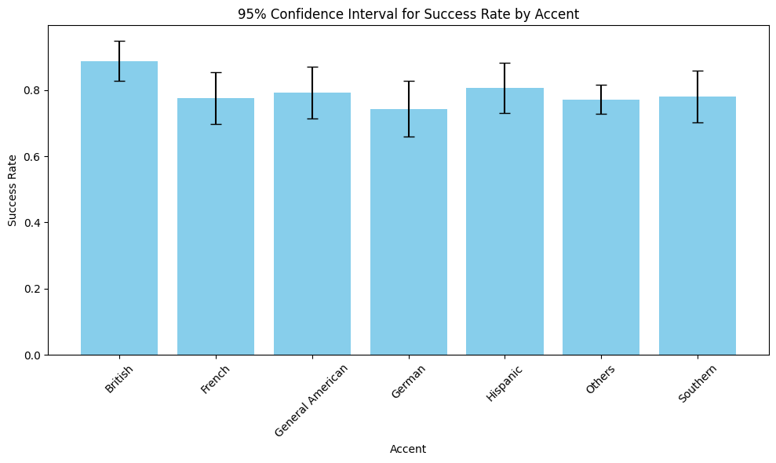

```python
# 3. Visualize the Results:
import matplotlib.pyplot as plt

# Plotting
plt.figure(figsize=(10,6))
plt.bar(accent_success.index, accent_success['success_rate'], yerr=accent_success['margin_of_error'], capsize=5, color='skyblue')
plt.ylabel('Success Rate')
plt.xlabel('Accent')
plt.title('95% Confidence Interval for Success Rate by Accent')
plt.xticks(rotation=45)
plt.tight_layout()
plt.show()
```

## Question 3 **Machine Learning & Modeling:**

Scenario: Apple is very keen on understanding how different devices might influence Siri's comprehension. Train a classification model using relevant features to predict the `Success` column. Evaluate your model's performance using a confusion matrix and other metrics. What insights can you derive from your model regarding Siri's performance across different devices?

**Hints:**:

1. **Data Preprocessing**: Check for missing values and handle them. Convert categorical variables into numerical values. Split the data into training and testing sets.
2. **Feature Selection**: Decide which features are relevant to predict the success of Siri's comprehension.
3. **Model Selection and Training**: Choose a classification model, train it using the training dataset.
4. **Model Evaluation**: Use the test dataset to evaluate the model's performance using confusion matrix and other metrics.
5. **Insight Generation**: Based on the model's feature importance and its performance, generate insights.

```python
# 1. Data Preprocessing:
import pandas as pd
from sklearn.model_selection import train_test_split
from sklearn.preprocessing import LabelEncoder

df = df_SiriVoiceLogs.copy()

# Handle missing values (dropping Feedback as it's optional and textual)
df.drop(columns=['Feedback'], inplace=True)
df.dropna(inplace=True)

# Convert categorical variables into numerical format
label_encoders = {}
for column in ['Command', 'Region', 'Accent', 'Device']:
    le = LabelEncoder()
    df[column] = le.fit_transform(df[column])
    label_encoders[column] = le

# 2. Feature Selection:
# Splitting data into training and testing sets
X = df.drop(columns=['Success', 'DateTime', 'UserID'])
y = df['Success']
X_train, X_test, y_train, y_test = train_test_split(X, y, test_size=0.2, random_state=42)

# 3. Model Selection and Training:
from sklearn.ensemble import RandomForestClassifier

# Train the model
clf = RandomForestClassifier(random_state=42)
clf.fit(X_train, y_train)
```

```
RandomForestClassifier(random_state=42)
```

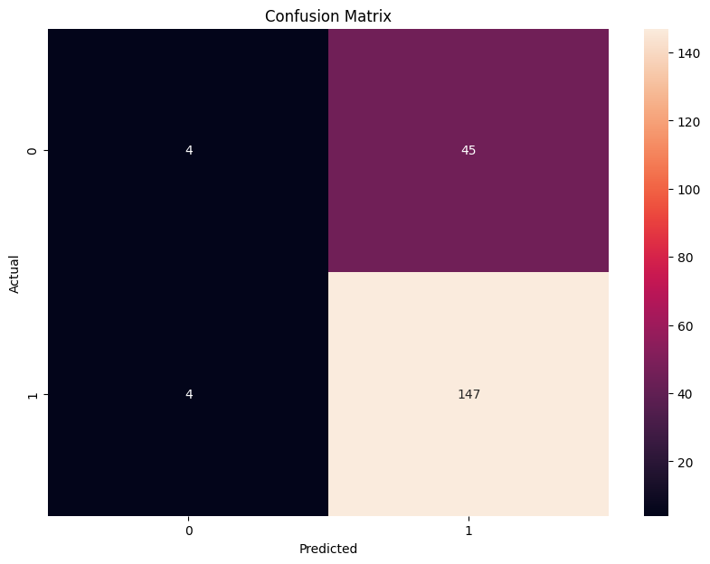

```
Accuracy: 0.755
              precision    recall  f1-score   support

           0       0.50      0.08      0.14        49
           1       0.77      0.97      0.86       151

    accuracy                           0.76       200
   macro avg       0.63      0.53      0.50       200
weighted avg       0.70      0.76      0.68       200
```

```python
# 4. Model Evaluation:
from sklearn.metrics import confusion_matrix, accuracy_score, classification_report
import matplotlib.pyplot as plt
import seaborn as sns

# Predictions
y_pred = clf.predict(X_test)

# Confusion Matrix
cm = confusion_matrix(y_test, y_pred)
plt.figure(figsize=(10,7))
sns.heatmap(cm, annot=True, fmt='g')
plt.title('Confusion Matrix')
plt.xlabel('Predicted')
plt.ylabel('Actual')
plt.show()

print("Accuracy:", accuracy_score(y_test, y_pred))
print(classification_report(y_test, y_pred))
```

```python
# 5. Insight Generation:
feature_importances = pd.DataFrame(clf.feature_importances_, index=X_train.columns, columns=['importance']).sort_values('importance', ascending=False)
print(feature_importances)
```

```
         importance
Command    0.341701
Accent     0.239971
Device     0.227008
Region     0.191320
```

## Question 4: **Product Design & Analytics:**

Scenario: Siri's team has recently made a software update aiming to improve Siri's understanding of certain regional accents. Using the data post the update timestamp (assume a date for this scenario), can you design an A/B test to assess if the update has indeed improved Siri's performance for these specific accents?

**A/B Test Design:**

1. **Objective**:
   - Determine whether the software update has enhanced Siri's comprehension of specific regional accents.
2. **Hypothesis**:
   - H0 (Null Hypothesis): The software update has no impact on Siri's performance for the targeted regional accents.
   - H1 (Alternative Hypothesis): The software update has improved Siri's performance for the targeted regional accents.
3. **Data Segmentation**:
   - Segment the data post the given update timestamp. Let's assume the update date was "1st September 2023".
   - From the segmented data, identify and isolate the records corresponding to the specific regional accents the update was aimed at.
4. **Test Design**:
   - **Control Group (A)**: Data from users with targeted accents who have not yet received the update. This could be achieved by rolling out the update in phases, holding back from a certain portion of the user base initially.
   - **Treatment Group (B)**: Data from users with targeted accents who have received the software update.
5. **Duration**:
   - The test should run long enough to gather a significant amount of data. Depending on Siri's usage frequency, this could range from a few weeks to a couple of months.
6. **Metrics**:
   - **Primary Metric**: The success rate (percentage of commands Siri correctly understood) for each group. A significantly higher success rate in Group B compared to Group A would suggest the update is effective.
   - **Secondary Metrics**: User feedback on misunderstandings, frequency of use (to understand if improved comprehension leads to increased usage), and the types of commands that see the most improvement.
7. **Statistical Significance**:
   - Use statistical tests (like a two-proportion z-test) to determine if the difference in the success rates between the two groups is statistically significant.
   - A significance level (alpha) of 0.05 is commonly used, meaning we would want to be 95% confident in the results to reject the null hypothesis.
8. **Considerations**:
   - **External Factors**: Ensure no other major updates or changes occur during the testing period that might affect Siri's performance.
   - **Bias**: Be cautious of potential biases. For instance, users in the treatment group might use Siri more frequently after the update, knowing an update was rolled out. This could affect the data.
9. **Analysis and Conclusion**:
   - After the test duration, analyze the results. If the success rate for the treatment group is significantly higher and the results are statistically significant, we can conclude that the software update was effective for the targeted accents.
   - If there's no significant difference, further investigation might be needed to understand why the update did not bring about the desired improvement.
10. **Rollout**:
    - If the test indicates a positive impact, consider rolling out the update to all users and monitor feedback and performance on a larger scale.

By following this A/B test design, we can obtain a clearer picture of whether the software update indeed had a beneficial effect on Siri's understanding of the targeted regional accents.